# DA 606 Final Project

# 1. Introduction:

**Research question:**

What can we learn about the American presidential election process by studying the candidates:

- Number of Contributions
- Total Contributions
- Average Contribution
- Where the candidate falls on the political spectrum
- Who received the largest donations?
- How big are the donation? (1st-3rd Quartiles)
- Are there donation patterns across the left-to-right political spectrum?
- Are there relationsips between donations and other features of the candidate?
- Does testing a subset of the data, due to hardware limits, produce a statistically accurate snapshot of the donations?

[figure not shown]

**Why we should care:**

- We should care about the number of, sizes, and totals of contributions to help us see if our government is truly serving its people, or rather serving special interests.

# 2. Data:

**Data collection:**

- Election Data was downloaded and loaded from: http://www.fec.gov/disclosurep/PDownload.do
- Political Spectrum information about the candidates was taken from: http://www.huffingtonpost.com/findthebest-/every-2016-candidate-from_b_7562176.html

**Cases:**

- Each case in this study was an individual campaign contribution.

**Variables:**

- The two (groups of) variables that will be studied are 1) Contributions, and 2) Candidate Political Spectrum Score:
- Note that after analysis, the most relevant of the contribution statistics will be used (of contribution total, contribution mean, and contribution_count)

**Type of study:**

**Scope of inference:**

# 3. Exploratory data analysis:

## 3A) The Candidates, Donations, and the Candidates’ Spectrum:

Next, since the presidential candidates were a small set of data, data was manually copied from http://www.huffingtonpost.com/findthebest-/every-2016-candidate-from_b_7562176.html into a data frame.

Below are the relevant features from this set of data:

|  | cand_nm | contbr_city | contbr_st | contb_receipt_amt | spectrum_score | party |
| --- | --- | --- | --- | --- | --- | --- |
| 25200 | Clinton, Hillary Rodham | NEW YORK | NY | 1797625 | -6.8 | Democrat |
| 447586 | Clinton, Hillary Rodham | NEW YORK | NY | 1467071 | -6.8 | Democrat |
| 447767 | Kasich, John R. | CINCINNATI | OH | 25000 | 5.0 | Republican |
| 30771 | Carson, Benjamin S. | ASPEN | CO | 18000 | 5.8 | Republican |
| 301848 | Kasich, John R. | COLUMBUS | OH | 16200 | 5.0 | Republican |
| 420274 | Bush, Jeb | PITTSBURG | TX | 15000 | 4.8 | Republican |

## 3B) Analyze total contributions per candidate:

|  | candidate | millions |
| --- | --- | --- |
| 10 | Clinton, Hillary Rodham | 50.2837224 |
| 4 | Cruz, Rafael Edward ‘Ted’ | 15.9249934 |
| 1 | Bush, Jeb | 14.5015898 |
| 8 | Rubio, Marco | 12.4079950 |
| 11 | Sanders, Bernard | 12.1700804 |
| 2 | Carson, Benjamin S. | 11.0681784 |
| 6 | Kasich, John R. | 3.4609306 |
| 3 | Christie, Christopher J. | 3.3025935 |
| 5 | Fiorina, Carly | 2.9850523 |
| 7 | Paul, Rand | 2.7226717 |
| 9 | Trump, Donald J. | 0.8447776 |

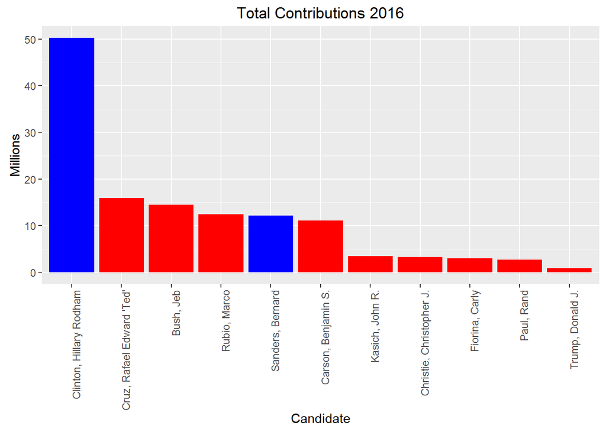

## 3C) Analyze contribution MEAN by spectrum score:

|  | spectrum_score | dollars |
| --- | --- | --- |
| 2 | 2.5 | 1359.65151 |
| 5 | 5.0 | 1135.47590 |
| 4 | 4.8 | 719.70375 |
| 10 | -6.8 | 482.64806 |
| 7 | 6.8 | 453.70758 |
| 3 | 4.0 | 328.19642 |
| 1 | 2.2 | 187.18953 |
| 8 | 8.0 | 161.28045 |
| 6 | 5.8 | 126.00816 |
| 9 | -8.5 | 74.80948 |

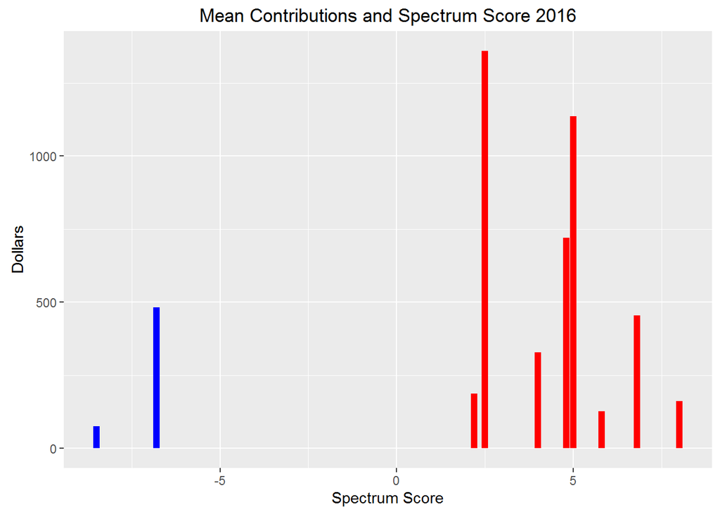

## 3D) Contribution Totals by party:

| party | millions |
| --- | --- |
| Republican | 67.21878 |
| Democrat | 62.45380 |

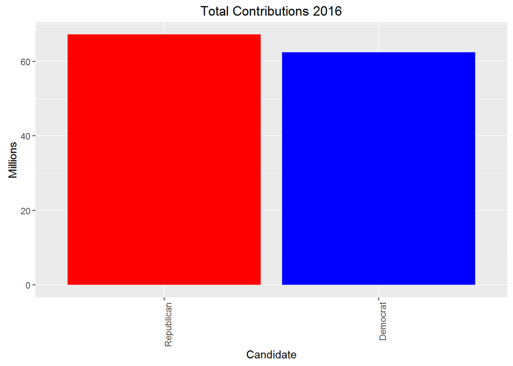

## 3E) Average Joe (mean contributions by candidate):

Let’s take a look at the MEAN contributions per candidate:

|  | candidate | dollars |
| --- | --- | --- |
| 3 | Christie, Christopher J. | 1359.65151 |
| 1 | Bush, Jeb | 1202.45355 |
| 6 | Kasich, John R. | 1135.47590 |
| 10 | Clinton, Hillary Rodham | 482.64806 |
| 8 | Rubio, Marco | 453.70758 |
| 9 | Trump, Donald J. | 328.19642 |
| 5 | Fiorina, Carly | 243.93661 |
| 7 | Paul, Rand | 187.18953 |
| 4 | Cruz, Rafael Edward ‘Ted’ | 161.28045 |
| 2 | Carson, Benjamin S. | 126.00816 |
| 11 | Sanders, Bernard | 74.80948 |

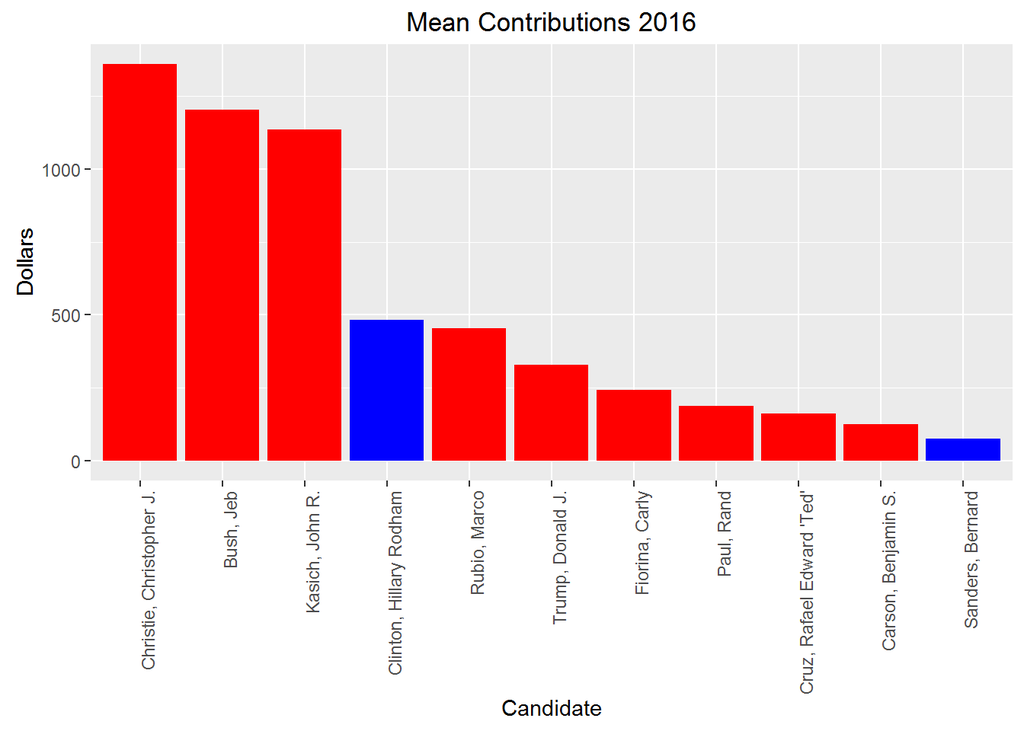

## 3F) Contribution Counts:

How many UNIQUE contributions per candidate:

|  | candidate | contr_count |
| --- | --- | --- |
| 11 | Sanders, Bernard | 162681 |
| 10 | Clinton, Hillary Rodham | 104183 |
| 4 | Cruz, Rafael Edward ‘Ted’ | 98741 |
| 2 | Carson, Benjamin S. | 87837 |
| 8 | Rubio, Marco | 27348 |
| 7 | Paul, Rand | 14545 |
| 5 | Fiorina, Carly | 12237 |
| 1 | Bush, Jeb | 12060 |
| 6 | Kasich, John R. | 3048 |
| 9 | Trump, Donald J. | 2574 |
| 3 | Christie, Christopher J. | 2429 |

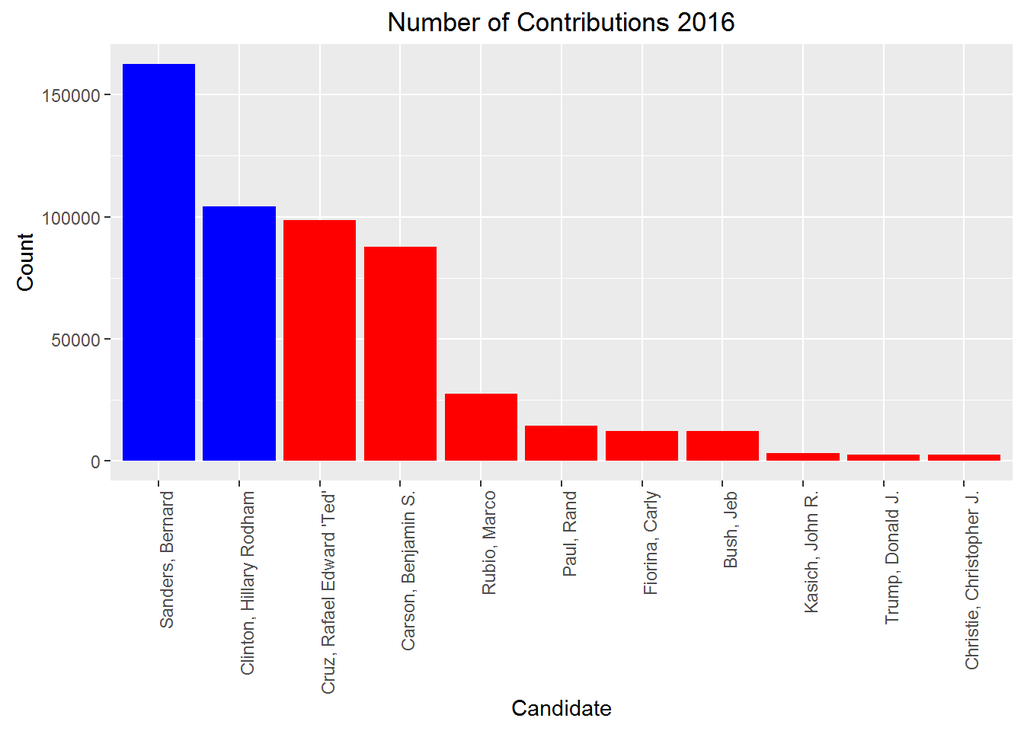

## 3G) Another vantage point of the data from above in a single plot:

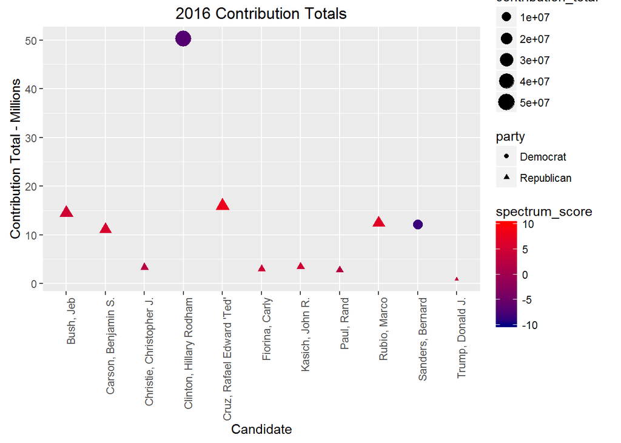

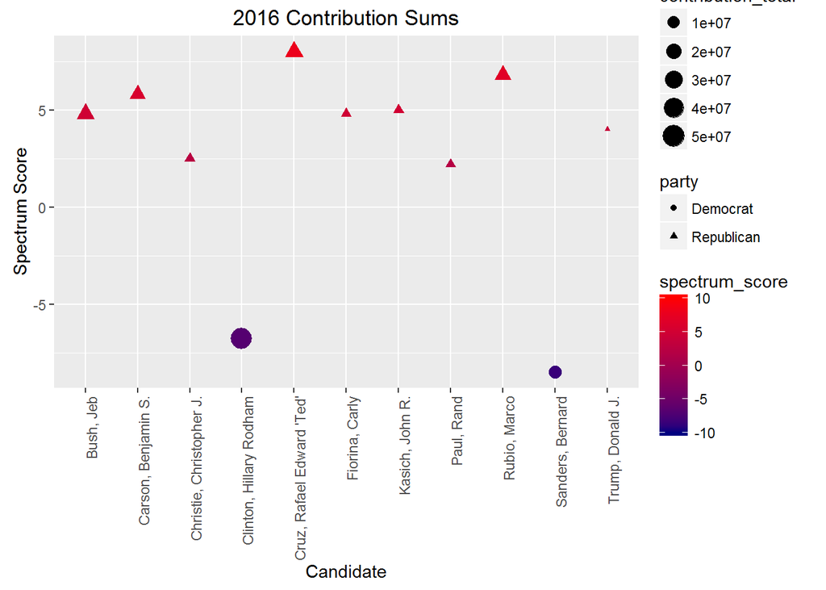

## 3H) Check the T-Distributions:

```
##
## Call:
## lm(formula = spectrum_score ~ contribution_count + contribution_total +
##     contribution_mean + party, data = summary_df)
##
## Residuals:
##     Min      1Q  Median      3Q     Max
## -1.9317 -0.6077  0.2556  0.6071  1.4567
##
## Coefficients:
##                      Estimate Std. Error t value Pr(>|t|)
## (Intercept)        -1.393e+01  2.555e+00  -5.451 0.001586 **
## contribution_count  2.457e-05  1.459e-05   1.685 0.143024
## contribution_total  9.772e-08  4.302e-08   2.271 0.063556 .
## contribution_mean  -1.856e-04  1.148e-03  -0.162 0.876883
## partyRepublican     1.747e+01  1.926e+00   9.070 0.000101 ***
## ---
## Signif. codes:  0 '***' 0.001 '**' 0.01 '*' 0.05 '.' 0.1 ' ' 1
##
## Residual standard error: 1.342 on 6 degrees of freedom
## Multiple R-squared:  0.9622, Adjusted R-squared:  0.9371
## F-statistic: 38.22 on 4 and 6 DF,  p-value: 0.0002093
```

The **partyRepublican** asterisk does not tell us much, as we know that the spectrum score is correlated to the political party.

## 3I) Population % vs. Donation %:

http://www.census.gov/popest/data/national/totals/2015/files/NST-EST2015-alldata.csv

| state | POPULATION | party | contrb_total | pct_pop | pct_contr | contr_score |
| --- | --- | --- | --- | --- | --- | --- |
| AL | 4858979 | Democrat | 184206.59 | 0.0075745 | 0.0014585 | 0.1925557 |
| AL | 4858979 | Republican | 797399.46 | 0.0075745 | 0.0063136 | 0.8335414 |
| AK | 738432 | Democrat | 78998.78 | 0.0011511 | 0.0006255 | 0.5433831 |
| AK | 738432 | Republican | 133299.84 | 0.0011511 | 0.0010554 | 0.9168861 |
| AZ | 6828065 | Democrat | 563318.98 | 0.0106440 | 0.0044602 | 0.4190376 |
| AZ | 6828065 | Republican | 1205195.26 | 0.0106440 | 0.0095425 | 0.8965119 |
| AR | 2978204 | Democrat | 344434.18 | 0.0046426 | 0.0027272 | 0.5874191 |
| AR | 2978204 | Republican | 276989.25 | 0.0046426 | 0.0021931 | 0.4723944 |
| CA | 39144818 | Democrat | 13007544.31 | 0.0610214 | 0.1029911 | 1.6877857 |
| CA | 39144818 | Republican | 8159785.45 | 0.0610214 | 0.0646075 | 1.0587678 |

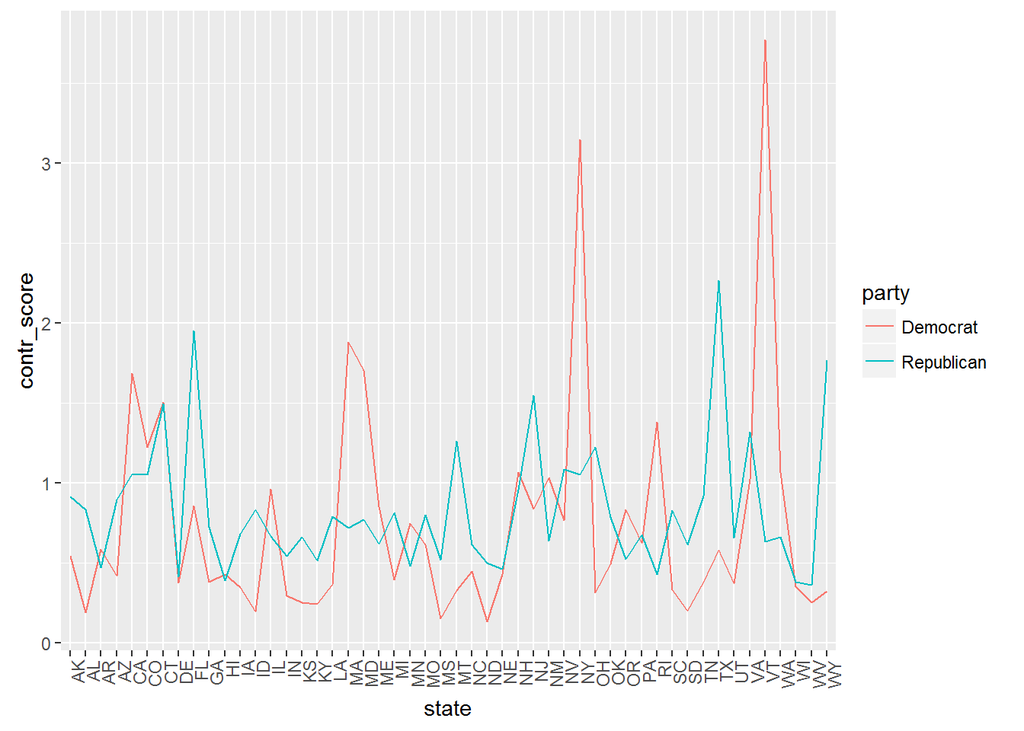

```
##
## Call:
## lm(formula = contr_score ~ us_pop + party, data = state_donations_df)
##
## Residuals:
##     Min      1Q  Median      3Q     Max
## -0.6210 -0.3717 -0.1692  0.1429  3.0157
##
## Coefficients: (1 not defined because of singularities)
##                 Estimate Std. Error t value Pr(>|t|)
## (Intercept)      0.75530    0.08189   9.224 5.85e-15 ***
## us_pop                NA         NA      NA       NA
## partyRepublican  0.08129    0.11580   0.702    0.484
## ---
## Signif. codes:  0 '***' 0.001 '**' 0.01 '*' 0.05 '.' 0.1 ' ' 1
##
## Residual standard error: 0.579 on 98 degrees of freedom
## Multiple R-squared:  0.005004,   Adjusted R-squared:  -0.00515
## F-statistic: 0.4928 on 1 and 98 DF,  p-value: 0.4843
```

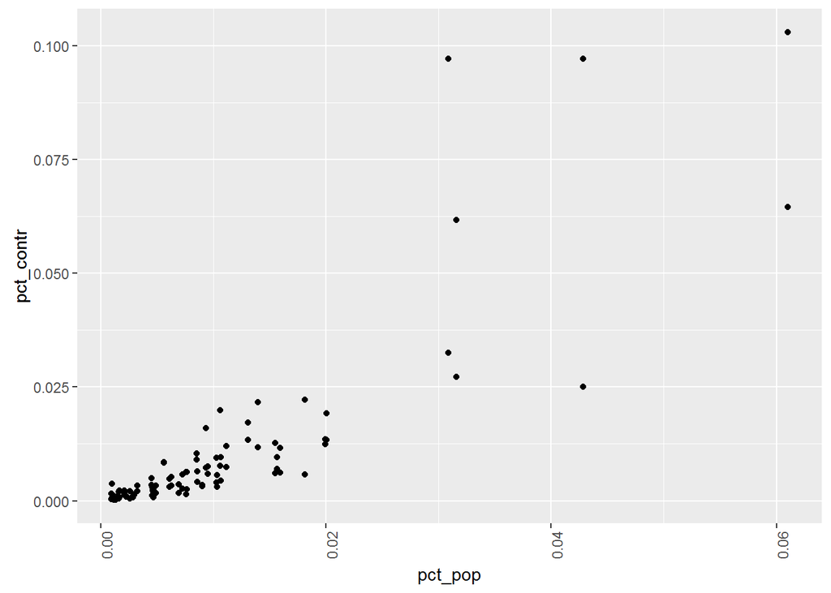

```
##
## Call:
## lm(formula = pct_contr ~ pct_pop, data = state_donations_df)
##
## Residuals:
##       Min        1Q    Median        3Q       Max
## -0.032024 -0.003900  0.000393  0.002800  0.057231
##
## Coefficients:
##              Estimate Std. Error t value Pr(>|t|)
## (Intercept) -0.004324   0.001319  -3.279  0.00144 **
## pct_pop      1.432375   0.088027  16.272  < 2e-16 ***
## ---
## Signif. codes:  0 '***' 0.001 '**' 0.01 '*' 0.05 '.' 0.1 ' ' 1
##
## Residual standard error: 0.00982 on 98 degrees of freedom
## Multiple R-squared:  0.7299, Adjusted R-squared:  0.7271
## F-statistic: 264.8 on 1 and 98 DF,  p-value: < 2.2e-16
```

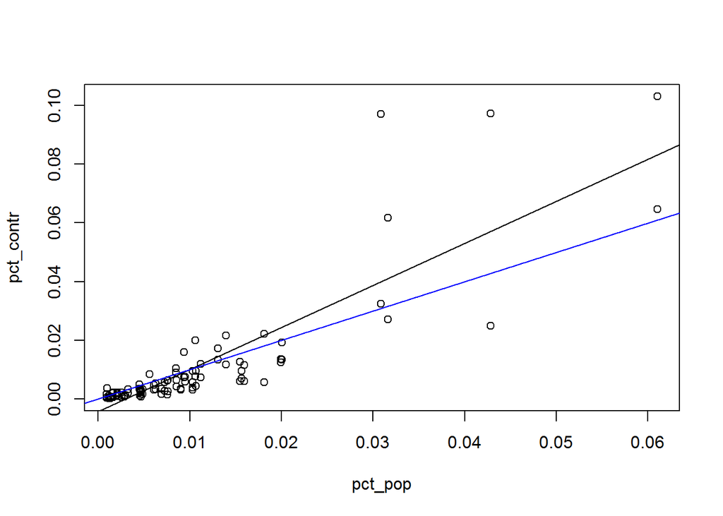

Note that in the above chart, the mean abline is blue, while the actual is black. It seems that the states that represent larger percentages of the overall population actually donate a higher **Percentage** than their state counterparts.

# 4. Inference:

It seems that the difference in the numbers of candidates running in each party makes it difficult to do any nominee-to-nominee comparisons. With that said, let’s look to some of the other possible models and see if they have any more strong correlations:

```
##
## Call:
## lm(formula = contribution_count ~ spectrum_score + party, data = summary_df)
##
## Residuals:
##    Min     1Q Median     3Q    Max
## -39198 -20131 -15833  25062  48063
##
## Coefficients:
##                 Estimate Std. Error t value Pr(>|t|)
## (Intercept)       222969      52583   4.240  0.00284 **
## spectrum_score     11704       6146   1.904  0.09333 .
## partyRepublican  -251080      81276  -3.089  0.01491 *
## ---
## Signif. codes:  0 '***' 0.001 '**' 0.01 '*' 0.05 '.' 0.1 ' ' 1
##
## Residual standard error: 33300 on 8 degrees of freedom
## Multiple R-squared:  0.7115, Adjusted R-squared:  0.6393
## F-statistic: 9.863 on 2 and 8 DF,  p-value: 0.006932
```

```
##
## Call:
## lm(formula = contribution_total ~ spectrum_score + party, data = summary_df)
##
## Residuals:
##       Min        1Q    Median        3Q       Max
## -16180480  -3937072  -1565424   4097702  16180480
##
## Coefficients:
##                  Estimate Std. Error t value Pr(>|t|)
## (Intercept)      57113967   14432552   3.957  0.00419 **
## spectrum_score    3383930    1686861   2.006  0.07976 .
## partyRepublican -66151272   22307920  -2.965  0.01800 *
## ---
## Signif. codes:  0 '***' 0.001 '**' 0.01 '*' 0.05 '.' 0.1 ' ' 1
##
## Residual standard error: 9140000 on 8 degrees of freedom
## Multiple R-squared:  0.6534, Adjusted R-squared:  0.5667
## F-statistic:  7.54 on 2 and 8 DF,  p-value: 0.01444
```

```
##
## Call:
## lm(formula = contribution_mean ~ spectrum_score + party, data = summary_df)
##
## Residuals:
##    Min     1Q Median     3Q    Max
## -587.1 -326.6 -186.8  416.6  619.2
##
## Coefficients:
##                 Estimate Std. Error t value Pr(>|t|)
## (Intercept)      -283.40     780.86  -0.363    0.726
## spectrum_score    -73.48      91.27  -0.805    0.444
## partyRepublican  1219.37    1206.95   1.010    0.342
##
## Residual standard error: 494.5 on 8 degrees of freedom
## Multiple R-squared:  0.1347, Adjusted R-squared:  -0.08158
## F-statistic: 0.6228 on 2 and 8 DF,  p-value: 0.5605
```

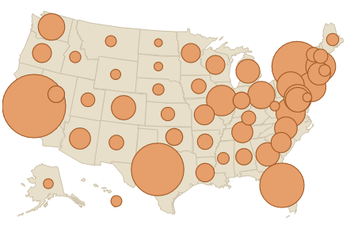

# 5. Conclusion

**My Findings:**

- There were other interesting data sets available, such as WHO the donations came from, when in the campaign lifecycle they came, etc.
- I normally pictured these data sets with very “distinct” columns, ie - with truly distinct meanings. This data set showed me that you can create fields with different meanings, all based on the same data (ie - dollars per contribution, total contributions, total number of contributions - all the same data, but different underlying meanings.)
- Based on this project, some questions that I would be curious about in the future are:
- Which types of groups are donating the large amounts?
- Which companies are truly just ‘bribing’ their candidates by contributing to all the candidates.
- System memory limits really were an issue. I knew that this was a problem in industry, but was not really expecting to get so many out-of-memory errors running Rmd scripts.